# Messy Data Exploration Exercise

2025-02-13

```r
library(tidyverse)
```

# Task 1

visualizing your data is important! summary statistics can be highly misleading, and simply plotting the data can reveal a lot more! Lets look at the Anscombe’s Quartet data. There are four different data sets. Anscombe, F. J. (1973). “Graphs in Statistical Analysis”. American Statistician. 27 (1): 17–21. doi:10.1080/00031305.1973.10478966. JSTOR 2682899.

```r
anscombe_quartet = readRDS("anscombe quartet.rds")
```

## Explore dataset

```r
str(anscombe_quartet)
```

```
## tibble [44 × 3] (S3: tbl_df/tbl/data.frame)
##  $ dataset: chr [1:44] "dataset_1" "dataset_1" "dataset_1" "dataset_1" ...
##  $ x      : num [1:44] 10 8 13 9 11 14 6 4 12 7 ...
##  $ y      : num [1:44] 8.04 6.95 7.58 8.81 8.33 ...
```

### what does the function str() do?

It shows us the elements in a dataset. In this case it shows us the values under each character.

# let’s check some summary statistics:

```r
anscombe_quartet %>%
  group_by(dataset) %>%
  summarise(
    mean_x    = mean(x),
    mean_y    = mean(y),
    min_x     = min(x),
    min_y     = min(y),
    max_x     = max(x),
    max_y     = max(y),
    crrltn    = cor(x, y)
  )
```

```
## # A tibble: 4 × 8
##   dataset   mean_x mean_y min_x min_y max_x max_y crrltn
##   <chr>      <dbl>  <dbl> <dbl> <dbl> <dbl> <dbl>  <dbl>
## 1 dataset_1      9   7.50     4  4.26    14 10.8   0.816
## 2 dataset_2      9   7.50     4  3.1     14  9.26  0.816
## 3 dataset_3      9   7.5      4  5.39    14 12.7   0.816
## 4 dataset_4      9   7.50     8  5.25    19 12.5   0.817
```

### what do the summary statistics tell us about the different datasets?

# let’s plot the data with ggplot:

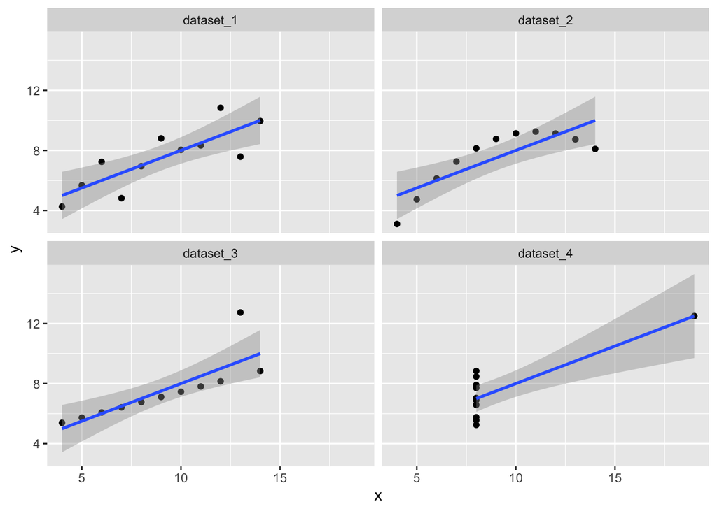

```r
library(ggplot2)
p1 <- ggplot(anscombe_quartet, aes(x=x,y=y)) +
  geom_point() +
  geom_smooth(method = "lm",formula = "y ~ x") +
  facet_wrap(~dataset)
p1
```

### What do the plots tell us about the different datasets?

### Describe the relationship between x and y in the different datasets.

Dataset1 has data points quite randomly distributed around the line of best fit, showing a common positive correlation between x and y. Dataset 2 has data points like a bell curve, can be acturally showing a process. Dataset 3 is more uniform with one outlier changing the angle of the line of best fit. Dataset 4 should have had a r squre of 0 but it has an extreme outlier in it, changing the expression of whole dataset.

### Would linear regression be an appropriate statistical model to analyse the x-y relationship in each dataset?

For dataset 1-3, linear regression would potentially be able to predict the value of y based on x. They don’t deviate much from the line of best fit. Dataset4 is more difficult to be analysed by regression since the extreme outlier changed the general statistical relationship between x and y. The line of best fit is just not able to describe x and y in dataset4.

### What conclusions can you draw for the plots and summary statistics?

Descriptive statstics is unable to fully illustrate the properties of a dataset. Outliers can be huge disturbance to the inferential statistics of a dataset.

# Task 2

### Load in the datasaurus dataset

```r
datasaurus_dozen = readRDS("datasaurus_dozen.rds")
```

### Explore the different datasets in datasaurus_dozen

```r
str(datasaurus_dozen)
```

```
## tibble [1,846 × 3] (S3: tbl_df/tbl/data.frame)
##  $ dataset: chr [1:1846] "dino" "dino" "dino" "dino" ...
##  $ x      : num [1:1846] 55.4 51.5 46.2 42.8 40.8 ...
##  $ y      : num [1:1846] 97.2 96 94.5 91.4 88.3 ...
##  - attr(*, "spec")=
##   .. cols(
##   ..   dataset = col_character(),
##   ..   x = col_double(),
##   ..   y = col_double()
##   .. )
```

### Print descriptive statistics and make a nicely formatted table

```r
datasaurus_dozen %>%
  group_by(dataset) %>%
  summarise(
    mean_x    = mean(x),
    mean_y    = mean(y),
    min_x     = min(x),
    min_y     = min(y),
    max_x     = max(x),
    max_y     = max(y),
    crrltn    = cor(x, y)
  )
```

```
## # A tibble: 13 × 8
##    dataset    mean_x mean_y min_x   min_y max_x max_y  crrltn
##    <chr>       <dbl>  <dbl> <dbl>   <dbl> <dbl> <dbl>   <dbl>
##  1 away         54.3   47.8  15.6  0.0151  91.6  97.5 -0.0641
##  2 bullseye     54.3   47.8  19.3  9.69    91.7  85.9 -0.0686
##  3 circle       54.3   47.8  21.9 16.3     85.7  85.6 -0.0683
##  4 dino         54.3   47.8  22.3  2.95    98.2  99.5 -0.0645
##  5 dots         54.3   47.8  25.4 15.8     78.0  94.2 -0.0603
##  6 h_lines      54.3   47.8  22.0 10.5     98.3  90.5 -0.0617
##  7 high_lines   54.3   47.8  17.9 14.9     96.1  87.2 -0.0685
##  8 slant_down   54.3   47.8  18.1  0.304   95.6  99.6 -0.0690
##  9 slant_up     54.3   47.8  20.2  5.65    95.3  99.6 -0.0686
## 10 star         54.3   47.8  27.0 14.4     86.4  92.2 -0.0630
## 11 v_lines      54.3   47.8  30.4  2.73    89.5  99.7 -0.0694
## 12 wide_lines   54.3   47.8  27.4  0.217   77.9  99.3 -0.0666
## 13 x_shape      54.3   47.8  31.1  4.58    85.4  97.8 -0.0656
```

### Calculate the correlations for x and y

(Done in the last step already though)

```r
datasaurus_dozen %>%
  group_by(dataset) %>%
  summarise(cor(x, y))
```

```
## # A tibble: 13 × 2
##    dataset    `cor(x, y)`
##    <chr>            <dbl>
##  1 away           -0.0641
##  2 bullseye       -0.0686
##  3 circle         -0.0683
##  4 dino           -0.0645
##  5 dots           -0.0603
##  6 h_lines        -0.0617
##  7 high_lines     -0.0685
##  8 slant_down     -0.0690
##  9 slant_up       -0.0686
## 10 star           -0.0630
## 11 v_lines        -0.0694
## 12 wide_lines     -0.0666
## 13 x_shape        -0.0656
```

### Plot the data

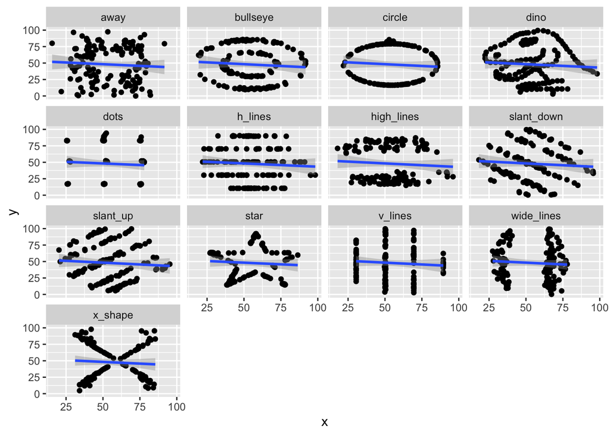

```r
p2 <- ggplot(datasaurus_dozen, aes(x=x,y=y)) +
  geom_point() +
  geom_smooth(method = "lm",formula = "y ~ x") +
  facet_wrap(~dataset)
p2
```

Ohh I get it. It’s the dataset showing how datasets with same means can be super different.